# R Notebook

# Display the new predictions

#I changed only 3 values. That’s why we only got first 3 different values of the previous one

```r
new_predictions
```

```
       1        2        3
13.07195 13.24775 12.93549
```

#Identify missing values

```r
is.na(wine)
```

[output not shown]

[output cut: 202 more lines]

#We use this code to view the sum of null values

```r
colSums(is.na(wine))
```

```
           Type         Alcohol           Malic             Ash      Alcalinity
              0               0               0               0               0
      Magnesium         Phenols      Flavanoids   Nonflavanoids Proanthocyanins
              0               0               0               0               0
          Color             Hue        Dilution         Proline
              0               0               0               0
```

#Data visualization

#Box Plot: Alcohol Content by Wine Class #Type: This is a variable in the dataset that likely represents different categories or groups (e.g., different types of wine).

```r
library(ggplot2)
```

[figure not shown]

[figure not shown]

```r
ggplot(wine, aes(x = as.factor(Type), y = Alcohol)) +
  geom_boxplot() +
  labs(title = "Scatter Plot of Alcohol vs Malic Acid",
       x = "Alcohol Content",
       y = "Malic Acid",
       color = "Type of Wine")
```

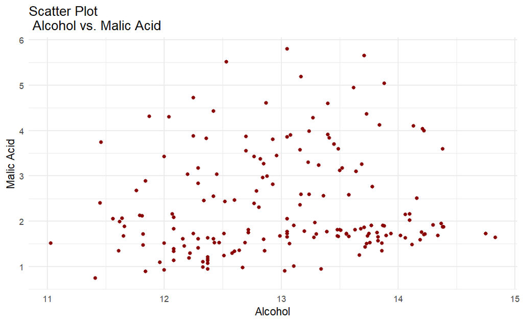

```r
ggplot(wine, aes(x = Alcohol, y = Malic, color = as.factor(Class))) +
  geom_point(color = "darkred") +
  labs(title = "Scatter Plot \n Alcohol vs. Malic Acid",
       x = "Alcohol",
       y = "Malic Acid",
       color = "Wine Class") +
  theme_minimal()
```

#This is how we add variable colours to points to the scatter plot

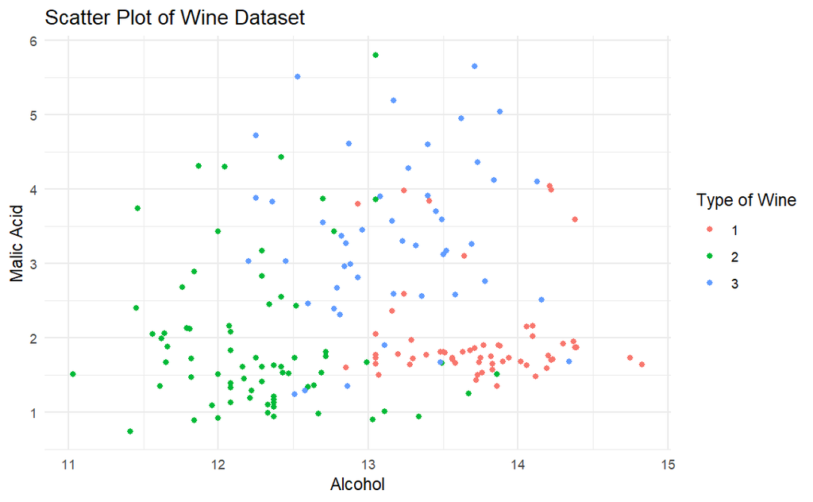

```r
ggplot(wine, aes(x = Alcohol, y = Malic, color = as.factor(Type))) +
  geom_point() +
  labs(title = "Scatter Plot of Wine Dataset",
       x = "Alcohol",
       y = "Malic Acid",
       color = "Type of Wine") +
  theme_minimal()
```

#Fit a linear regression model

```r
model <- lm(Alcohol ~ Malic + Ash, data = wine)
summary(model)
```

```
Call:
lm(formula = Alcohol ~ Malic + Ash, data = wine)

Residuals:
     Min       1Q   Median       3Q      Max
-1.94267 -0.55275 -0.02601  0.59612  1.97759

Coefficients:
            Estimate Std. Error t value Pr(>|t|)
(Intercept) 11.48551    0.52145  22.026  < 2e-16 ***
Malic        0.04458    0.05432   0.821  0.41297
Ash          0.59621    0.22121   2.695  0.00772 **
---
Signif. codes:  0 ‘***’ 0.001 ‘**’ 0.01 ‘*’ 0.05 ‘.’ 0.1 ‘ ’ 1

Residual standard error: 0.7964 on 175 degrees of freedom
Multiple R-squared:  0.04841,   Adjusted R-squared:  0.03754
F-statistic: 4.452 on 2 and 175 DF,  p-value: 0.01301
```

# Visualize the regression model

# Scatter plot with regression line for Alcohol vs Malic_Acid

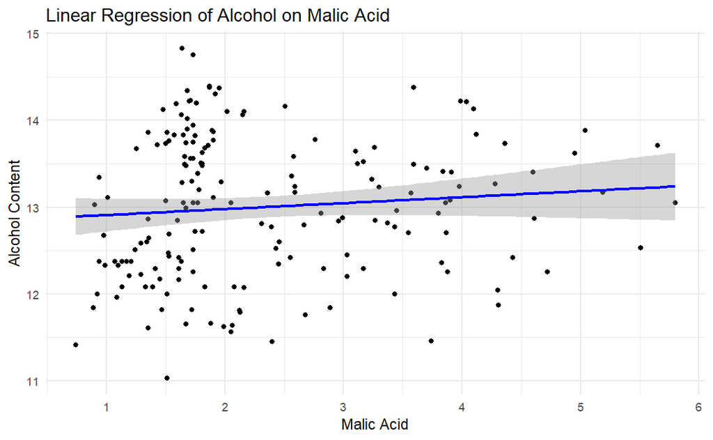

```r
ggplot(wine, aes(x = Malic, y = Alcohol)) +
  geom_point() +
  geom_smooth(method = "lm", col = "blue") +
  labs(
    title = "Linear Regression of Alcohol on Malic Acid",
    x = "Malic Acid",
    y = "Alcohol Content"
  ) +
  theme_minimal()
```

#Scatter plot with regression line for Alcohol vs Ash

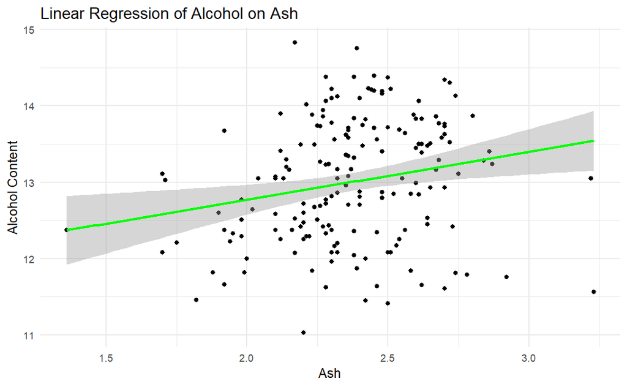

```r
ggplot(wine, aes(x = Ash, y = Alcohol)) +
  geom_point() +
  geom_smooth(method = "lm", col = "green") +
  labs(
    title = "Linear Regression of Alcohol on Ash",
    x = "Ash",
    y = "Alcohol Content"
  ) +
  theme_minimal()
```

#Above script will fit a linear regression model to predict alcohol content based on Malic_Acid and Ash, and create visualizations to help you understand the relationships between these variables.

#Bar chart #Create a bar chart for the count of each wine type

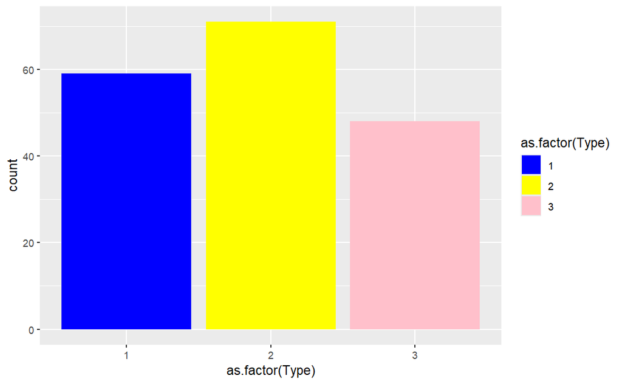

```r
ggplot(wine, aes(x = as.factor(Type),fill = as.factor(Type))) +
  geom_bar() +
  scale_fill_manual(values = c("blue","yellow","pink"))
```

```r
  labs(
    title = "Count of Each Wine Type",
    x = "Wine Type",
    y = "Count",
  ) +
  theme_minimal()
```

#Average Alcohol Content per Wine Type # Calculate the average alcohol content per wine type

```r
average_alcohol <- aggregate(Alcohol ~ Type, data = wine, FUN = mean)
```

#Create a bar chart for the average alcohol content:

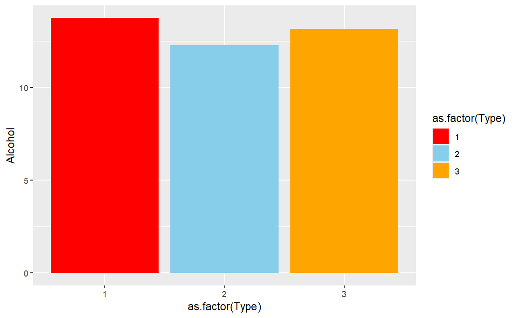

```r
ggplot(average_alcohol, aes(x = as.factor(Type), y = Alcohol,fill = as.factor(Type))) +
  geom_bar(stat = "identity") +
  scale_fill_manual(values = c("red","skyblue","orange"))
```

```r
  labs(
    title = "Average Alcohol Content per Wine Type",
    x = "Wine Type",
    y = "Average Alcohol Content"
  ) +
  theme_minimal()
```

#Pie chart # Calculate the count of each wine type #first call the dplyr package

```r
library(dplyr)
```

```r
wine_count <- wine %>%
  group_by(Type) %>%
  summarise(Count = n())
```

# Add a column for labels

```r
wine_count <- wine_count %>%
  mutate(Label = paste0("Type ", Type, ": ", Count))
```

# Create the pie chart

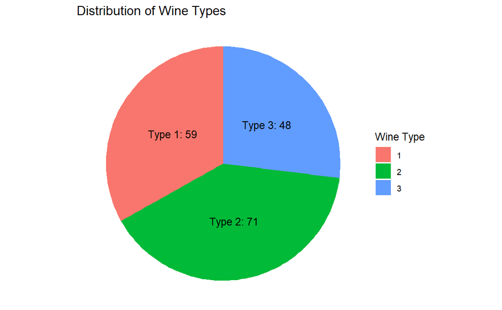

```r
ggplot(wine_count, aes(x = "", y = Count, fill = as.factor(Type))) +
  geom_bar(width = 1, stat = "identity") +
  coord_polar("y") +
  labs(
    title = "Distribution of Wine Types",
    fill = "Wine Type"
  ) +
  theme_void() +
  theme(legend.position = "right") +
  geom_text(aes(label = Label), position = position_stack(vjust = 0.5))
```

#Average Alcohol Content per Wine Type # Calculate the average alcohol content per wine type

```r
average_alcohol <- wine %>%
  group_by(Type) %>%
  summarise(Average_Alcohol = mean(Alcohol))
```

# Add a column for labels

```r
average_alcohol <- average_alcohol %>%
  mutate(Label = paste0("Type ", Type, ": ", round(Average_Alcohol, 2)))
```

# Create the pie chart

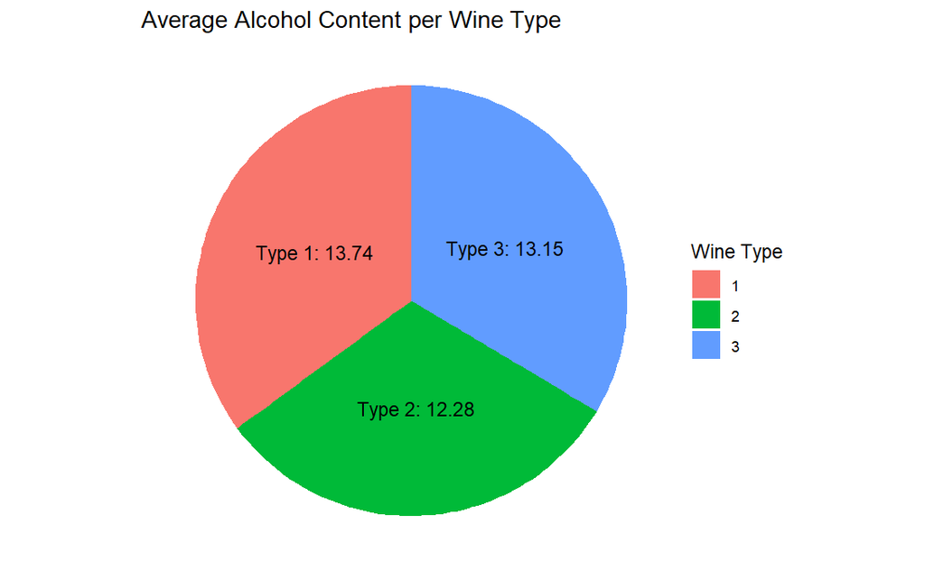

```r
ggplot(average_alcohol, aes(x = "", y = Average_Alcohol, fill = as.factor(Type))) +
  geom_bar(width = 1, stat = "identity") +
  coord_polar("y") +
  labs(
    title = "Average Alcohol Content per Wine Type",
    fill = "Wine Type"
  ) +
  theme_void() +
  theme(legend.position = "right") +
  geom_text(aes(label = Label), position = position_stack(vjust = 0.5))
```

#Levels in variables

#Levels in Type variables

```r
unique(wine$Type)
```

```
[1] 1 2 3
Levels: 1 2 3
```

#Levels in Alcohol variables

```r
unique(wine$Alcohol)
```

```
  [1] 14.23 13.20 13.16 14.37 13.24 14.20 14.39 14.06 14.83 13.86 14.10 14.12 13.75 14.75
 [15] 14.38 13.63 14.30 13.83 14.19 13.64 12.93 13.71 12.85 13.50 13.05 13.39 13.30 13.87
 [29] 14.02 13.73 13.58 13.68 13.76 13.51 13.48 13.28 13.07 14.22 13.56 13.41 13.88 14.21
 [43] 13.90 13.94 13.82 13.77 13.74 13.29 13.72 12.37 12.33 12.64 13.67 12.17 13.11 13.34
 [57] 12.21 12.29 13.49 12.99 11.96 11.66 13.03 11.84 12.70 12.00 12.72 12.08 12.67 12.16
 [71] 11.65 11.64 12.69 11.62 12.47 11.81 12.60 12.34 11.82 12.51 12.42 12.25 12.22 11.61
 [85] 11.46 12.52 11.76 11.41 11.03 12.77 11.45 11.56 11.87 12.07 12.43 11.79 12.04 12.86
 [99] 12.88 12.81 12.53 12.84 13.36 13.52 13.62 12.87 13.32 13.08 12.79 13.23 12.58 13.17
[113] 13.84 12.45 14.34 12.36 13.69 12.96 13.78 13.45 12.82 13.40 12.20 14.16 13.27 14.13
```

#Levels in Malic variables

```r
unique(wine$Malic)
```

```
  [1] 1.71 1.78 2.36 1.95 2.59 1.76 1.87 2.15 1.64 1.35 2.16 1.48 1.73 1.81 1.92 1.57 1.59
 [18] 3.10 1.63 3.80 1.86 1.60 2.05 1.77 1.72 1.90 1.68 1.50 1.66 1.83 1.53 1.80 1.65 3.99
 [35] 3.84 1.89 3.98 4.04 3.59 2.02 1.75 1.67 1.70 1.97 1.43 0.94 1.10 1.36 1.25 1.13 1.45
 [52] 1.21 1.01 1.17 1.19 1.61 1.51 1.09 1.88 0.90 2.89 0.99 3.87 0.92 3.86 0.89 0.98 2.06
 [69] 1.33 2.83 1.99 1.52 2.12 1.41 1.07 3.17 2.08 1.34 2.45 2.55 1.29 3.74 2.43 2.68 0.74
 [86] 1.39 1.47 3.43 2.40 4.43 5.80 4.31 2.13 4.30 2.99 2.31 3.55 1.24 2.46 4.72 5.51 2.96
[103] 2.81 2.56 4.95 3.88 3.57 5.04 4.61 3.24 3.90 3.12 2.67 3.30 5.19 4.12 3.03 3.83 3.26
[120] 3.27 3.45 2.76 4.36 3.70 3.37 2.58 4.60 2.39 2.51 5.65 3.91 4.28 4.10
```

#Levels in Ash variables

```r
unique(wine$Ash)
```

```
 [1] 2.43 2.14 2.67 2.50 2.87 2.45 2.61 2.17 2.27 2.30 2.32 2.41 2.39 2.38 2.70 2.72 2.62 2.48
[19] 2.56 2.28 2.65 2.36 2.52 3.22 2.80 2.21 2.84 2.55 2.10 2.51 2.31 2.12 2.59 2.29 2.44 2.40
[37] 2.04 2.60 2.42 2.68 2.25 2.46 1.36 2.02 1.92 2.16 2.53 1.70 1.75 2.24 1.71 2.23 1.95 2.00
[55] 2.20 2.58 2.26 2.22 2.74 1.98 1.90 1.88 1.94 1.82 2.92 1.99 2.19 3.23 2.73 2.13 2.78 2.54
[73] 2.64 2.35 2.15 2.75 2.69 2.86 2.37
```

#Levels in Alcalinity variables

```r
unique(wine$Alcalinity)
```

```
 [1] 15.6 11.2 18.6 16.8 21.0 15.2 14.6 17.6 14.0 16.0 18.0 11.4 12.0 17.2 20.0 16.5 16.6 17.8
[19] 25.0 16.1 17.0 19.4 22.5 19.1 19.5 19.0 20.5 15.5 13.2 16.2 18.8 15.0 17.5 18.9 17.4 12.4
[37] 17.1 16.4 16.3 16.7 10.6 18.1 19.6 20.4 24.0 30.0 14.8 23.0 22.8 26.0 21.6 23.6 18.5 22.0
[55] 20.7 21.5 20.8 28.5 26.5 24.5 23.5 25.5 27.0
```

#Levels in Magnesium variables

```r
unique(wine$Magnesium)
```

```
 [1] 127 100 101 113 118 112  96 121  97  98 105  95  89  91 102 120 115 108 116 126 124  93
[23]  94 107 106 104 132 110 128 117  90 103 111  92  88  87  78 151  86 139 136  85  99  84
[45]  70  81  80 162 134 119  82 122 123
```

#Levels in Phenols variables

```r
unique(wine$Phenols)
```

```
 [1] 2.80 2.65 3.85 3.27 2.50 2.60 2.98 2.95 2.20 3.10 3.30 2.85 2.70 3.00 2.41 2.61 2.48
[18] 2.53 2.63 2.40 2.86 2.42 2.35 2.45 3.15 3.25 2.64 2.75 2.88 2.72 3.88 2.96 3.20 3.40
[35] 1.98 2.05 2.02 2.10 3.50 1.89 2.11 1.85 1.10 1.88 3.38 1.61 1.95 1.72 1.90 2.83 2.00
[52] 1.65 1.78 1.92 1.60 1.45 1.38 3.02 2.55 3.52 2.23 2.56 1.68 2.36 2.74 3.18 1.75 2.46
[69] 1.63 2.90 2.62 2.13 2.22 1.51 1.30 1.15 1.70 1.62 1.79 2.32 1.54 1.40 1.55 1.50 0.98
[86] 1.93 1.41 1.48 1.80 1.74 2.30 1.83 1.39 1.35 1.28 1.25 1.59
```

#Levels in Flavanoids variables

```r
unique(wine$Flavanoids)
```

```
  [1] 3.06 2.76 3.24 3.49 2.69 3.39 2.52 2.51 2.98 3.15 3.32 2.43 3.69 3.64 2.91 3.14 3.40
 [18] 3.93 3.03 3.17 2.41 2.88 2.37 2.61 2.68 2.94 2.19 2.97 2.33 3.25 3.19 2.74 2.53 2.64
 [35] 3.04 3.29 3.56 2.63 3.00 2.65 2.92 3.54 3.27 2.99 3.74 2.79 2.90 2.78 3.23 3.67 0.57
 [52] 1.09 1.41 1.79 3.10 1.75 3.18 2.00 1.30 1.28 1.02 2.86 1.84 2.89 2.14 1.57 2.03 1.32
 [69] 1.85 2.55 2.26 1.58 1.59 2.21 1.94 1.69 1.61 1.50 1.25 1.46 2.25 2.27 0.99 2.50 3.75
 [86] 2.17 1.36 2.11 1.64 1.92 1.76 2.04 2.58 2.01 2.29 1.60 2.09 5.08 2.13 2.24 2.45 1.22
[103] 1.20 0.58 0.66 0.47 0.60 0.48 0.50 0.52 0.80 0.78 0.55 0.34 0.65 0.76 1.39 0.83 0.63
[120] 1.31 1.10 0.92 0.56 0.70 0.68 0.84 0.96 0.49 0.51 0.61 0.75 0.69
```

#Levels in Nonflavanoids variables

```r
unique(wine$Nonflavanoids)
```

```
 [1] 0.28 0.26 0.30 0.24 0.39 0.34 0.31 0.29 0.22 0.43 0.33 0.40 0.32 0.17 0.25 0.27 0.47
[18] 0.37 0.42 0.50 0.20 0.21 0.19 0.63 0.53 0.45 0.55 0.14 0.13 0.35 0.61 0.48 0.52 0.58
[35] 0.66 0.60 0.41 0.44 0.56
```

#Levels in Proanthocyanins variables

```r
unique(wine$Proanthocyanins)
```

```
  [1] 2.29 1.28 2.81 2.18 1.82 1.97 1.98 1.25 1.85 2.38 1.57 1.81 2.96 1.46 1.72 1.86 1.66
 [18] 2.10 1.69 1.92 1.45 1.35 1.76 1.95 1.54 1.36 1.44 1.37 2.08 2.34 1.48 1.70 2.03 2.19
 [35] 2.14 2.91 1.87 1.68 1.62 2.45 2.04 0.42 0.41 0.62 0.73 1.03 2.28 1.04 2.50 1.96 1.65
 [52] 1.15 0.95 2.76 1.43 1.77 1.40 2.35 1.56 1.34 1.38 1.64 1.63 1.99 3.28 1.31 1.42 2.49
 [69] 3.58 1.22 1.05 2.01 1.53 1.61 0.83 1.83 1.71 1.90 0.94 0.84 0.80 1.10 0.88 0.81 0.75
 [86] 0.64 0.55 1.02 1.14 1.30 0.68 0.86 1.26 1.55 2.70 0.96 0.97 1.11 1.24 1.06 1.41
```

#Levels in Color variables

```r
unique(wine$Color)
```

```
  [1]  5.640000  4.380000  5.680000  7.800000  4.320000  6.750000  5.250000  5.050000
  [9]  5.200000  7.220000  5.750000  5.000000  5.600000  5.400000  7.500000  7.300000
 [17]  6.200000  6.600000  8.700000  5.100000  5.650000  4.500000  3.800000  3.930000
 [25]  3.520000  3.580000  4.800000  3.950000  4.700000  5.700000  6.900000  3.840000
 [33]  4.200000  4.600000  4.250000  3.700000  6.130000  4.280000  5.430000  4.360000
 [41]  5.040000  5.240000  4.900000  6.100000  8.900000  7.200000  7.050000  6.300000
 [49]  5.850000  6.250000  6.380000  6.000000  6.800000  1.950000  3.270000  4.450000
 [57]  2.950000  5.300000  4.680000  3.170000  2.850000  3.050000  3.380000  3.740000
 [65]  3.350000  3.210000  2.650000  3.400000  2.570000  2.500000  3.900000  2.200000
 [73]  2.620000  2.450000  2.600000  2.800000  1.740000  2.400000  3.600000  2.150000
 [81]  3.250000  2.900000  2.300000  3.300000  2.060000  2.940000  2.700000  2.000000
 [89]  3.080000  1.900000  1.280000  2.080000  2.760000  3.940000  3.000000  2.120000
 [97]  4.100000  5.450000  7.100000  3.850000  4.920000  4.350000  4.400000  8.210000
[105]  4.000000  7.650000  8.420000  9.400000  8.600000 10.800000 10.520000  7.600000
[113]  7.900000  9.010000 13.000000 11.750000  5.880000  5.580000  5.280000  9.580000
[121]  6.620000 10.680000 10.260000  8.660000  8.500000  5.500000  9.899999  9.700000
[129]  7.700000 10.200000  9.300000  9.200000
```

#Levels in Hue variables

```r
unique(wine$Hue)
```

```
 [1] 1.040 1.050 1.030 0.860 1.020 1.060 1.080 1.010 1.250 1.170 1.150 1.200 1.280 1.070
[15] 1.130 1.230 0.960 1.090 1.110 1.120 0.920 1.190 1.100 1.180 0.890 0.950 0.910 0.880
[29] 0.820 0.870 1.240 0.980 0.940 1.220 1.450 0.906 1.360 1.310 0.990 1.380 1.160 0.840
[43] 0.790 1.330 1.000 1.420 1.270 0.800 0.750 0.900 0.930 1.710 0.700 0.730 0.690 0.970
[57] 0.760 0.740 0.660 0.780 0.810 0.770 0.650 0.600 0.580 0.540 0.550 0.570 0.590 0.480
[71] 0.610 0.560 0.670 0.680 0.850 0.720 0.620 0.640
```

#Levels in Dilution variables

```r
unique(wine$Dilution)
```

```
  [1] 3.92 3.40 3.17 3.45 2.93 2.85 3.58 3.55 2.82 2.90 2.73 3.00 2.88 2.65 2.57 3.36 3.71
 [18] 3.52 4.00 3.63 3.82 3.20 3.22 2.77 3.59 2.71 2.87 3.47 2.78 2.51 2.69 3.53 3.38 3.56
 [35] 3.35 3.33 3.44 2.75 3.10 2.91 3.37 3.26 3.03 3.31 2.84 1.82 1.67 1.59 2.46 2.23 2.30
 [52] 3.18 3.48 1.93 3.07 3.16 3.50 3.13 2.14 2.48 2.52 2.31 3.12 3.14 2.72 2.01 3.08 2.26
 [69] 3.21 2.27 2.06 3.30 2.96 2.63 2.74 2.83 2.44 3.57 2.42 3.02 2.81 2.50 3.19 2.12 3.05
 [86] 3.39 3.69 3.64 3.28 1.29 1.42 1.36 1.51 1.58 1.27 1.69 2.15 2.47 2.05 2.00 1.68 1.33
[103] 1.86 1.62 1.30 1.47 1.55 1.48 1.64 1.73 1.96 1.78 2.11 1.75 1.56 1.80 1.92 1.83 1.63
[120] 1.71 1.74 1.60
```

#Levels in Proline variables

```r
unique(wine$Proline)
```

```
  [1] 1065 1050 1185 1480  735 1450 1290 1295 1045 1510 1280 1320 1150 1547 1310 1130 1680
 [18]  845  780  770 1035 1015  830 1195 1285  915 1515  990 1235 1095  920  880 1105 1020
 [35]  760  795  680  885 1080  985 1060 1260 1265 1190 1375 1120  970 1270  520  450  630
 [52]  420  355  678  502  510  750  718  870  410  472  886  428  392  500  463  278  714
 [69]  515  495  562  625  480  290  345  937  660  406  710  438  415  672  315  488  312
 [86]  325  607  434  385  407  372  564  465  365  380  378  352  466  342  580  530  560
[103]  600  650  695  720  590  550  855  425  675  640  725  620  570  615  685  470  740
[120]  835  840
```

#Import shiny app

```r
library(shiny)
```

# Load the Wine dataset

```r
data(wine)
```

# Define UI for the app

```r
ui <- fluidPage(
  titlePanel("Wine Dataset Visualization"),

  sidebarLayout(
    sidebarPanel(
      selectInput("xvar", "X-axis Variable", choices = names(wine), selected = names(wine)[1]),
      selectInput("yvar", "Y-axis Variable", choices = names(wine), selected = names(wine)[2]),
      selectInput("colorvar", "Color By", choices = names(wine), selected = names(wine)[3])
    ),

    mainPanel(
      plotOutput("scatterPlot")
    )
  )
)
```

# Define server logic

```r
server <- function(input, output) {

  output$scatterPlot <- renderPlot({
    ggplot(wine, aes_string(x = input$xvar, y = input$yvar, color = input$colorvar)) +
      geom_point() +
      labs(x = input$xvar, y = input$yvar, color = input$colorvar) +
      theme_minimal()
  })
}
```

# Run the application

```r
shinyApp(ui = ui, server = server)
```

```
Listening on http://127.0.0.1:6730
```

```
NA
```

# Histogram

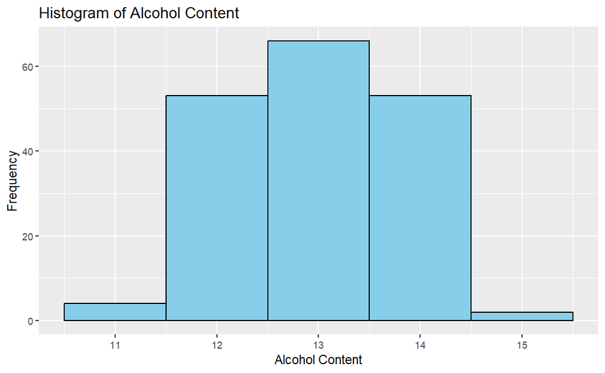

```r
ggplot(wine, aes(x = Alcohol)) +
  geom_histogram(binwidth = 1, fill = "skyblue", color = "black") +
  labs(title = "Histogram of Alcohol Content", x = "Alcohol Content", y = "Frequency")
```

# Density plot

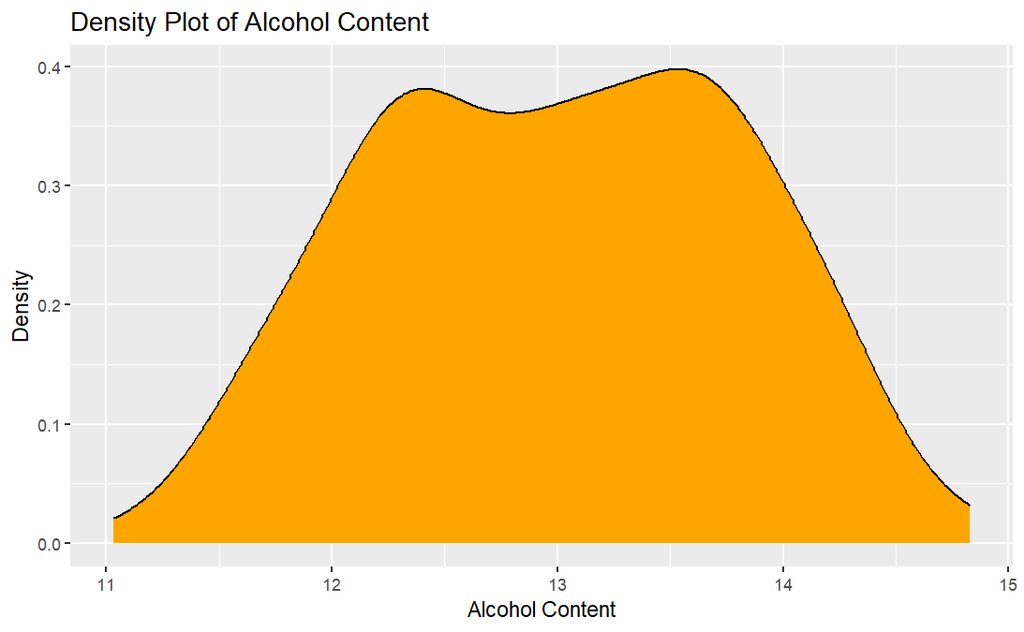

```r
ggplot(wine, aes(x = Alcohol)) +
  geom_density(fill = "orange", color = "black") +
  labs(title = "Density Plot of Alcohol Content", x = "Alcohol Content", y = "Density")
```